# Praca domowa 12

Agnieszka Sitko

## First model

First, I will create a really simple model, that may be presented by a formula: `thick ~ soil`. Statistic calculated for such a model are gathered below.

```
## Linear mixed-effects model fit by REML
##  Data: spdata
##       AIC      BIC    logLik
##   341.629 350.7909 -166.8145
##
## Random effects:
##  Formula: ~1 | dummy
##         (Intercept) Residual
## StdDev:   0.7014883  2.27815
##
## Fixed effects: thick ~ soil
##                Value Std.Error DF  t-value p-value
## (Intercept) 31.94203  3.233986 73 9.876984  0.0000
## soil         2.25521  0.865589 73 2.605407  0.0111
##  Correlation:
##      (Intr)
## soil -0.973
##
## Standardized Within-Group Residuals:
##         Min          Q1         Med          Q3         Max
## -2.65190771 -0.52564305  0.03844187  0.65121160  2.17651608
##
## Number of Observations: 75
## Number of Groups: 1
```

P-value calculated for `soil` shows that the relation between this variable and `thick` is significant. Estimated parameter shows that this relation is positive.

Dependence between `thick` and `soil` may be seen in a plot.

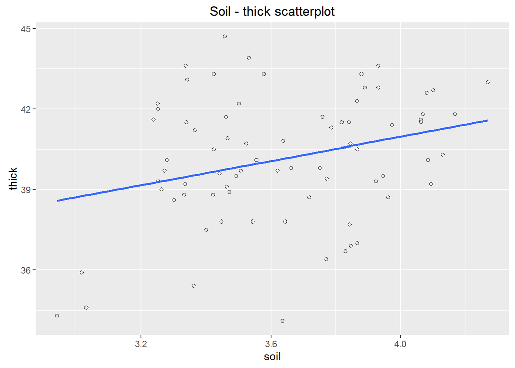

## Second model

Now, let’s see whether there is any significant spatial correlation between `thick` values.

```
## Monte-Carlo test
## Observation: 0.1925625
## Call: mantel.rtest(m1 = distSpatial, m2 = distThick)
## Based on 99 replicates
## Simulated p-value: 0.01
```

Mantel test confirms the existance of spatial correlation. Let’s built a model based on this assumption. To do so, I will include five different spatial correlation structres. Likelihoods for each model are presented below.

```
##          -     corExp    corGaus  corSphere     corLin   corRatio
## -166.81452  -79.55203  -40.75366 -167.15916  -78.73483  -23.01006
```

So it looks like the best fit is obtained with a rational quadratic spatial correlation structure. Let’s analyze the result of this model.

```
## Linear mixed-effects model fit by maximum likelihood
##  Data: spdata
##        AIC      BIC    logLik
##   56.02011 67.60755 -23.01006
##
## Random effects:
##  Formula: ~1 | dummy
##          (Intercept) Residual
## StdDev: 0.0001517928 2.553953
##
## Correlation Structure: Rational quadratic spatial correlation
##  Formula: ~east + north | dummy
##  Parameter estimate(s):
##    range
## 33.15116
## Fixed effects: thick ~ soil
##                Value Std.Error DF   t-value p-value
## (Intercept) 40.93084 1.3340861 73 30.680809  0.0000
## soil        -0.00414 0.0170917 73 -0.242092  0.8094
##  Correlation:
##      (Intr)
## soil -0.028
##
## Standardized Within-Group Residuals:
##        Min         Q1        Med         Q3        Max
## -2.6687252 -0.8091678 -0.3186991  0.3270839  1.4814168
##
## Number of Observations: 75
## Number of Groups: 1
```

We may observe that a model with a spatial correlation structure rejects significance of `soil` variable.

## Conclusion

Simple linear model with just one independent variable claims that there is a noticeable relation between `thick` and `soil`. However, models with exponential, gaussian, linear and rational quadratic correlation structure denies this relation. All of those model provide better fit for out data (according to the likelihood value). Therefore, we may say, that in our case it is crucial to include spatial correlation to get more reliable conclusions.